# Исследование закономерностей, определяющих успешность игры

### Посмотрите на общее распределение игр по жанрам. Что можно сказать о самых прибыльных жанрах? Выделяются ли жанры с высокими и низкими продажами?

```python
genres_df = (actual_games_df
             .pivot_table(index='genre', values='total_sales', aggfunc='sum')
             .reset_index()
            )
genres_df['market_share'] = round(genres_df['total_sales'] / genres_df['total_sales'].sum() * 100, 1)
genres_df
# создание сводной таблицы с суммой и процентом продаж по жанрам
```

|  | genre | total_sales | market_share |
| --- | --- | --- | --- |
| 0 | Action | 321.87 | 29.5 |
| 1 | Adventure | 23.64 | 2.2 |
| 2 | Fighting | 35.31 | 3.2 |
| 3 | Misc | 62.82 | 5.8 |
| 4 | Platform | 42.63 | 3.9 |
| 5 | Puzzle | 3.17 | 0.3 |
| 6 | Racing | 39.89 | 3.7 |
| 7 | Role-Playing | 145.89 | 13.4 |
| 8 | Shooter | 232.98 | 21.4 |
| 9 | Simulation | 21.76 | 2.0 |
| 10 | Sports | 150.65 | 13.8 |
| 11 | Strategy | 10.08 | 0.9 |

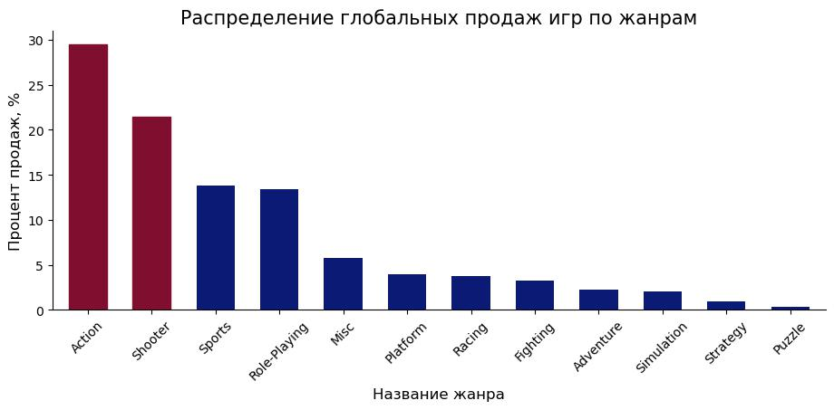

```python
fig = plt.figure(figsize=(11, 4))
ax1 = fig.add_subplot(1, 1, 1)
ax1.spines['top'].set_visible(False)
ax1.spines['right'].set_visible(False)
(genres_df
     .sort_values(by='market_share', ascending=False)
     .plot(y='market_share',
           x='genre',
           kind='bar',
           color='#0b1b75',
           legend=False,
           ax=ax1,
           width=0.6)
)
plt.title('Распределение глобальных продаж игр по жанрам', fontsize=15)
plt.ylabel('Процент продаж, %', fontsize=12)
plt.xlabel('Название жанра', fontsize=12)
plt.xticks(rotation = 45)
ax1.patches[0].set_color('#800f2f')
ax1.patches[1].set_color('#800f2f')

plt.show()
# построение столбчатой диараммы с процентом продаж в зависимости от жанра
```

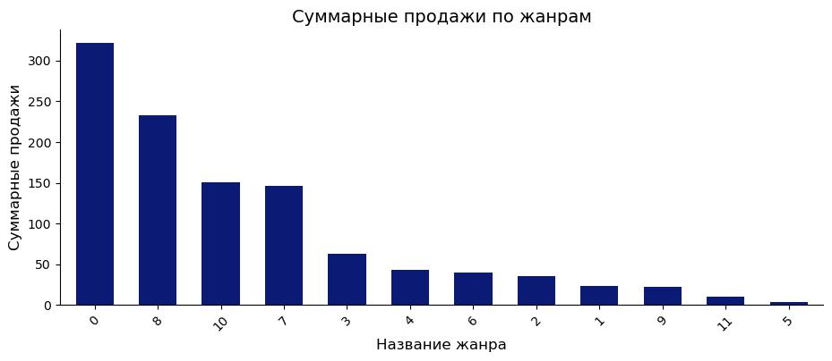

```python
fig = plt.figure(figsize=(11, 4))
ax1 = fig.add_subplot(1, 1, 1)
ax1.spines['top'].set_visible(False)
ax1.spines['right'].set_visible(False)
(genres_df
     .sort_values(by='total_sales', ascending=False)
     .plot(y='total_sales',
           kind='bar',
           color='#0b1b75',
           legend=False,
           ax=ax1,
           width=0.6)
)
plt.title('Суммарные продажи по жанрам', fontsize=14)
plt.ylabel('total_sales')
plt.xticks(rotation = 45)

plt.xlabel('Название жанра', fontsize=12)
plt.ylabel('Суммарные продажи', fontsize=12)
plt.show()
# построение столбчатой диаграммы: суммарные продажи по жанрам
```

```python
genres_df_mean = (actual_games_df
                      .pivot_table(index='genre',
                                   values='total_sales',
                                   aggfunc=['median', 'mean'])
                 )
genres_df_mean.columns = ['median_sales', 'mean_sales']
genres_df_mean['median_sales'] = round(genres_df_mean['median_sales'], 2)
genres_df_mean['mean_sales'] = round(genres_df_mean['mean_sales'], 2)
genres_df_mean
# создание сводной таблицы с медианной и средней суммой продаж по жанрам
```

| genre | median_sales | mean_sales |
| --- | --- | --- |
| Action | 0.11 | 0.42 |
| Adventure | 0.03 | 0.10 |
| Fighting | 0.12 | 0.44 |
| Misc | 0.10 | 0.41 |
| Platform | 0.22 | 0.58 |
| Puzzle | 0.06 | 0.19 |
| Racing | 0.12 | 0.47 |
| Role-Playing | 0.12 | 0.50 |
| Shooter | 0.45 | 1.25 |
| Simulation | 0.10 | 0.35 |
| Sports | 0.24 | 0.70 |
| Strategy | 0.08 | 0.18 |

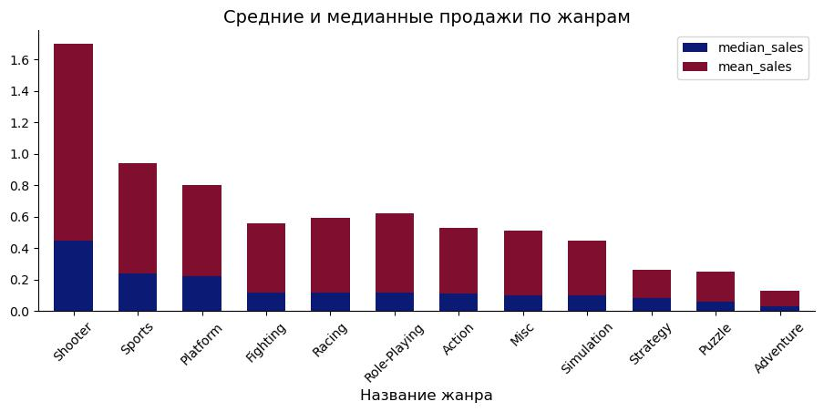

```python
fig = plt.figure(figsize=(11, 4))
ax1 = fig.add_subplot(1, 1, 1)
ax1.spines['top'].set_visible(False)
ax1.spines['right'].set_visible(False)
(genres_df_mean
     .sort_values(by='median_sales', ascending=False)
     .plot(kind='bar',
           color=['#0b1b75', '#800f2f'],
           legend=True,
           ax=ax1,
           width=0.6,
           stacked=True)
)
plt.title('Средние и медианные продажи по жанрам', fontsize=14)
plt.xticks(rotation = 45)
plt.xlabel('Название жанра', fontsize=12)

plt.show()
# построение столбчатой диаграммы: медианные и средние продажи по жанрам
```

Если рассматривать суммарные продажи, почти 1/3 рынка игр составляют **игры жанра "Action"**. Кроме того, самыми прибыльными жанрами являются шутеры, спортивные и ролевые игры. Игры жанра "Puzzle" продаются хуже всего. Шутеры и экшен-игры чаще привлекают геймеров своей визуальной и эмоциональной атмосферой, возможностью взаимодействовать в команде.

Однако, если учитывать медианные значения продаж, то на первое место выходят **шутеры** с показателем 450 тыс. копий на одну игру жанра. В тройку лидеров по медианным продажам также входят **спортивные игры и игры жанра "Платформер"**. При этом игры жанра "Action" занимают только лишь 7 место в рейтинге. Из-за присутствия в выборке игр-бестселлеров суммарные продажи отдельного жанра могут выглядеть высокими, в отличие от медианного показателя продаж на одну игру.

## Портрет пользователя каждого региона

```python
def print_local_df(region, feature):
    local_df = (actual_games_df
                .pivot_table(index=feature, values=region, aggfunc='sum')
                .sort_values(by=region, ascending=False).head(5)
               )

    fig1, ax1 = plt.subplots(figsize=(8, 4))
    fig1.suptitle(f'Распределение продаж игр: {feature}, {region}', fontsize=15)
    palette_color = sns.color_palette('seismic')
    ax1.pie(x=local_df[region],
            colors=palette_color,
            autopct='%.1f%%',
            startangle=90,
            shadow=True,
            pctdistance=1.2,
            labels=None)
    ax1.axis('equal')
    plt.legend(labels=local_df.index, loc='upper right', fontsize=12)
    plt.tight_layout()

    return plt.show()
# создание функции для построения круговых диаграмм
```

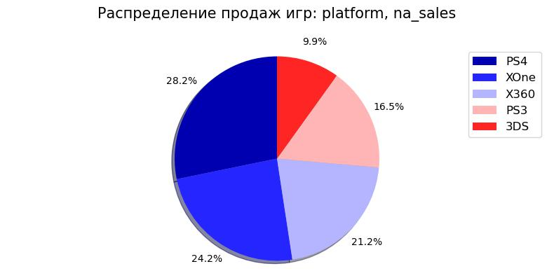

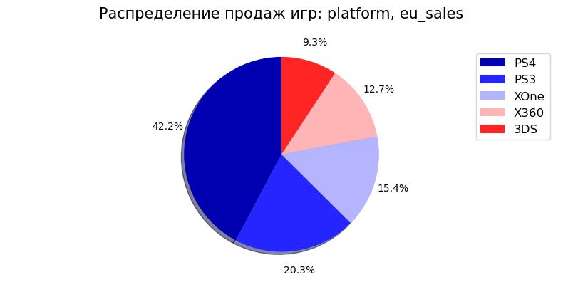

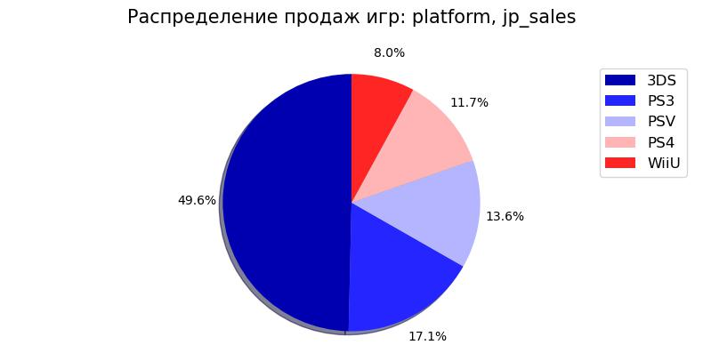

```python
local_list = ['na_sales', 'eu_sales', 'jp_sales']
for region in local_list:
    print_local_df(region, 'platform')
# применение функции для построения круговых диаграмм с долями продаж по платформам и в зависимости от региона
```

В Северной Америке и Европе чаще покупают игры на платформы от Microsoft ("XOne", "X360") и Sony Electronics ("PS3", "PS4"). При этом чаще покупатели **в Северной Америке** отдают предпочтение **Microsoft** (45% от продаж), а **в Европе** популярнее продукция **Sony Electronics** (62% от продаж).

На **японском рынке** ситуация другая. Там доминируют платформы от местного производителя **Nintendo** (58% от продаж).

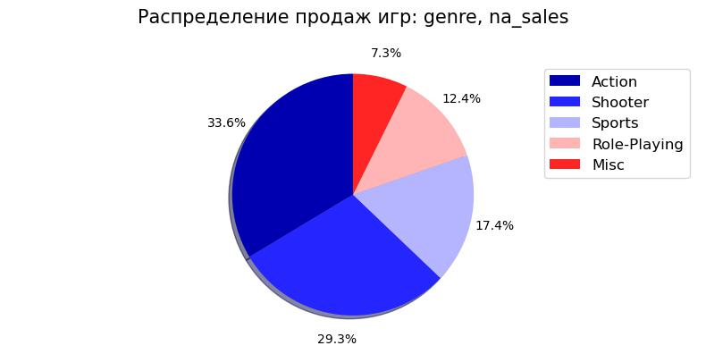

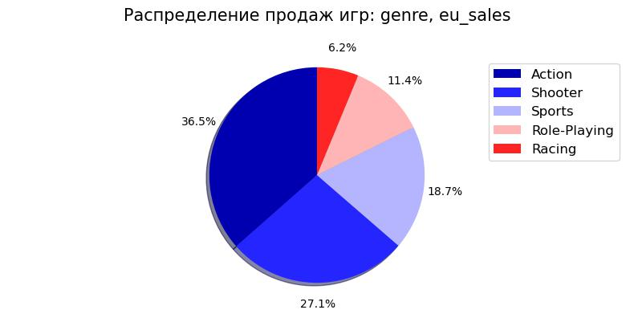

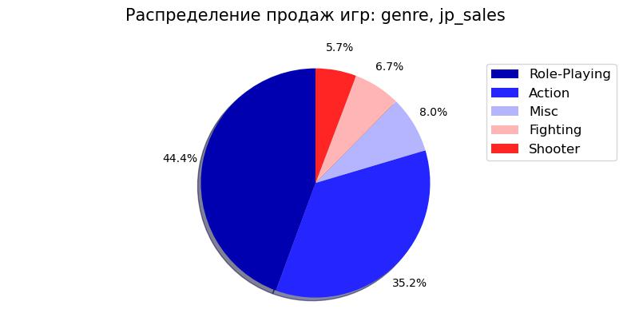

```python
local_list = ['na_sales', 'eu_sales', 'jp_sales']
for region in local_list:
    print_local_df(region, 'genre')
# применение функции для построения круговых диаграмм с долями продаж по жанрам и в зависимости от региона
```

Топ европейских жанров в целом похож на пятёрку самых распространённых жанров в Северной Америке: **экшен-игры, шутеры, спортивные и ролевые игры**. Единтсвенным отличием является наличие в американском "Топ-5" жанра "Misc", а в европейском - жанра гонок "Racing".

В Японии 44% рынка занимают **ролевые игры**. На втором месте жанр "Action". На шутеры приходится всего 5.7% от продаж.

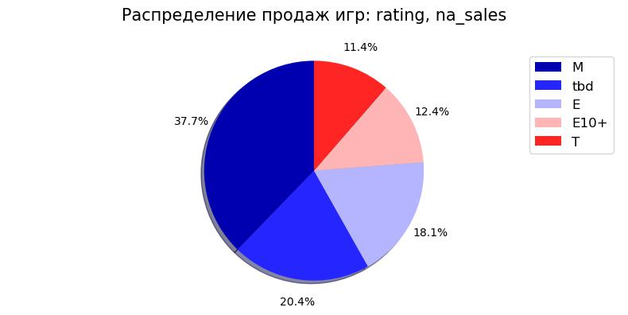

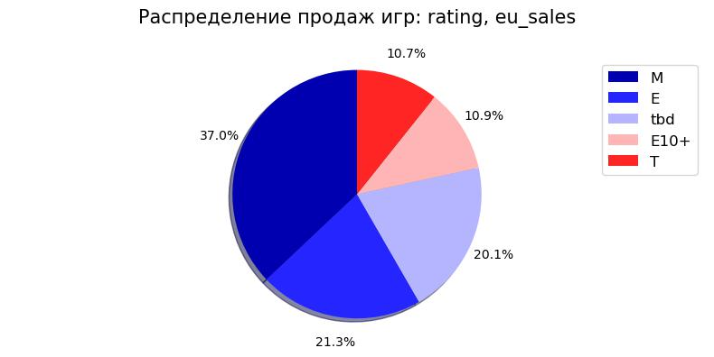

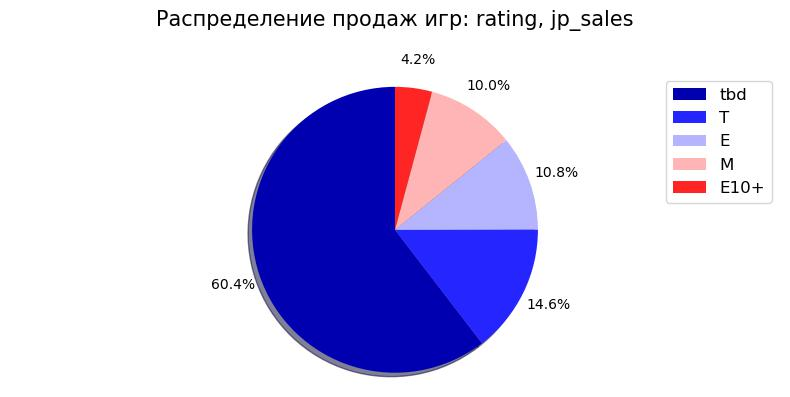

```python
for region in local_list:
    local_df = (actual_games_df
                .pivot_table(index='rating', values=region, aggfunc='sum')
                .sort_values(by=region, ascending=False)
               )

    fig1, ax1 = plt.subplots(figsize=(8, 4))
    fig1.suptitle(f'Распределение продаж игр: rating, {region}', fontsize=15)
    palette_color = sns.color_palette('seismic')
    ax1.pie(x=local_df[region],
            colors=palette_color,
            autopct='%.1f%%',
            startangle=90,
            shadow=True,
            pctdistance=1.2,
            labels=None)
    ax1.axis('equal')
    plt.legend(labels=local_df.index, loc='upper right', fontsize=12)
    plt.tight_layout()

    plt.show()
# построение круговых диаграмм с долями продаж по рейтингам и в зависимости от региона
```

В **Европе и Северной Америке** востребованы игры **для взрослой аудитории** (рейтинг 17+ "M").

На круговой диаграмме заметно, что **в Японии** 60% от продаж отводится играм **без рейтинга**. Дело в том, что в Японии возрастными рейтингами занимается некоммерческая организация "CERO", и поэтому точно оценить "Топ-5" возрастных рейтингов не получится.

## Проверка гипотез

### Проверим гипотезу: Средние пользовательские рейтинги платформ Xbox One и PC одинаковые.

```python
xone_df = actual_games_df[(actual_games_df['platform'] == 'XOne') & (~(actual_games_df['user_score'].isna()))]
pc_df = actual_games_df[(actual_games_df['platform'] == 'PC') & (~(actual_games_df['user_score'].isna()))]
# создание таблиц с данными по платформам "XOne" и "PC"
```

```python
print(xone_df['user_score'].describe())
print(f'Дисперсия равна: {round(np.var(xone_df["user_score"]), 3)}')
print(f'Стандартное отклонение равно: {round(np.std(xone_df["user_score"]), 3)}')
# подсчёт описательной статистики для "XOne"
```

```
count    182.000000
mean       6.521429
std        1.380941
min        1.600000
25%        5.800000
50%        6.800000
75%        7.500000
max        9.200000
Name: user_score, dtype: float64
Дисперсия равна: 1.897
Стандартное отклонение равно: 1.377
```

```python
print(pc_df['user_score'].describe())
print(f'Дисперсия равна: {round(np.var(pc_df["user_score"]), 3)}')
print(f'Стандартное отклонение равно: {round(np.std(pc_df["user_score"]), 3)}')
# подсчёт описательной статистики для "PC"
```

```
count    155.000000
mean       6.269677
std        1.742381
min        1.400000
25%        5.300000
50%        6.800000
75%        7.600000
max        9.300000
Name: user_score, dtype: float64
Дисперсия равна: 3.016
Стандартное отклонение равно: 1.737
```

Исходя из H0 формулируется альтернативная гипотеза H1. Это утверждение, которое принимается верным, если отбрасывается H0.

*Нулевая гипотеза (H0)*: Средние пользовательские рейтинги платформ Xbox One и PC **одинаковые**.

*Альтернативная гипотеза (H1)*: Средние пользовательские рейтинги платформ Xbox One и PC **различаются**.

```python
alpha = 0.01
# выбор уровня статистической значимости
```

```python
results = st.ttest_ind(xone_df['user_score'], pc_df['user_score'])

print('p-значение:', results.pvalue)

if results.pvalue < alpha:
    print('Отвергаем нулевую гипотезу')
else:
    print('Не получилось отвергнуть нулевую гипотезу')
# проверка гипотезы
```

```
p-значение: 0.14012658403611647
Не получилось отвергнуть нулевую гипотезу
```

### Проверим гипотезу: Средние пользовательские рейтинги жанров Action (англ. «действие», экшен-игры) и Sports (англ. «спортивные соревнования») разные.

```python
action_df = actual_games_df[(actual_games_df['genre'] == 'Action') & (~(actual_games_df['user_score'].isna()))]
sports_df = actual_games_df[(actual_games_df['genre'] == 'Sports') & (~(actual_games_df['user_score'].isna()))]
# создание таблиц с данными по жанрам "Action" и "Sports"
```

```python
print(action_df['user_score'].describe())
print(f'Дисперсия равна: {round(np.var(action_df["user_score"]), 3)}')
print(f'Стандартное отклонение равно: {round(np.std(action_df["user_score"]), 3)}')
# подсчёт описательной статистики для "Action"
```

```
count    389.000000
mean       6.837532
std        1.330173
min        2.000000
25%        6.300000
50%        7.100000
75%        7.800000
max        9.100000
Name: user_score, dtype: float64
Дисперсия равна: 1.765
Стандартное отклонение равно: 1.328
```

```python
print(sports_df['user_score'].describe())
print(f'Дисперсия равна: {round(np.var(sports_df["user_score"]), 3)}')
print(f'Стандартное отклонение равно: {round(np.std(sports_df["user_score"]), 3)}')
# подсчёт описательной статистики для "Sports"
```

```
count    160.000000
mean       5.238125
std        1.783427
min        0.200000
25%        4.100000
50%        5.500000
75%        6.500000
max        8.800000
Name: user_score, dtype: float64
Дисперсия равна: 3.161
Стандартное отклонение равно: 1.778
```

*Нулевая гипотеза (H0)*: Средние пользовательские рейтинги жанров Action и Sports **одинаковые**.

*Альтернативная гипотеза (HA)*: Средние пользовательские рейтинги жанров Action и Sports **различаются**.

```python
results = st.ttest_ind(sports_df['user_score'], action_df['user_score'])

print('p-значение:', results.pvalue)

if results.pvalue < alpha:
    print('Отвергаем нулевую гипотезу')
else:
    print('Не получилось отвергнуть нулевую гипотезу')
# проверка гипотезы
```

```
p-значение: 1.0517832389140023e-27
Отвергаем нулевую гипотезу
```

Значение p-value меньше уровня статистической значимости, значит, есть основание полагать, что **разница** между средними пользовательскими рейтингами жанров Action и Sports **статистически значима**.

## Общий вывод

С момента появления первых аркад мировой рынок игр постоянно претерпевал изменения. С 1980 до 1990 гг. происходило постепенное развитие игровых жанров, новые производители платформ выходили на рынок. Рост числа выпускаемых игр наряду с расширением технических возможностей операционных систем и интернета достиг максимального значения в 2009 г. После кризиса 2008 г. темп разработки игр для консолей начал падать. Появились мобильные игры, которые впоследствии заняли одну из лидирующих позиций на рынке. В то же время возникла новая тенденция к улучшению качества игр (их графики, сценариев), в результате чего среднее время разработки увеличилось.

На основе проведённого анализа были сделаны следующие выводы:

- Платформы-лидеры по суммарным глобальным продажам за всё время: "PS2", "X360", "PS3", "Wii", "DS" и "PS".
- За последние годы такие платформы как, "PS2", "PS3", "X360" уже начинают исчезать с рынка. На замену им выпускаются платформы нового поколения.
- Жизненный срок платформы составляет в среднем от 9 до 11 лет, а пик продаж приходится на 5-6 год.
- Среди потенциально прибыльных платформ стоит выделить "PS4" и "XOne". Они были выпущены на рынок в 2013 г. и к 2017 г. суммарные продажи игр уже могут достичь максимума. Кроме того, для данных платформ чаще выпускаются игры, которые в будущем становятся бестселлерами.
- Самое большое количество популярных кассовых игр относится к платформам "PS4" и "X360".
- Существует умеренная корреляция между оценками критиков и глобальными продажами для всех платформ. Корреляция с пользовательсикми оценками отсутсвует для всех, кроме "WiiU". Покупатели скорее учитывают профессиональное мнение критиков при выборе игр, чем полагаются на оценки других геймеров.
- Если рассматривать только суммарные продажи, то лидером является жанр "Action". Далее следуют шутеры, спортивные и ролевые игры. Однако, медианы продаж на одну игру самые высокие у шутеров, спортивных игр и игр жанра "Платформер". Такая разница обусловлена наличием в выборке выбросов (игр-бестселлеров) с рекордными продажами.
- Пользователи из Северной Америки предпочитают консоли Microsoft ("XOne", "X360"), экшен-игры, шутеры, спортивные и ролевые игры.
- Пользователи из Европы выбирают платформы от Sony ("PS3", "PS4"), экшен-игры, шутеры, спортивные игры и гонки. Также как и в Северной Америке востребованы игры с рейтингом "M".
- В Японии вкусы у пользователей отличаются от американских и европейских. Больше половины рынка занимают игры для консолей японской компании Nintendo. Пользуются спросом ролевые игры, также выбирают и "Action". У большинства игр неизвестен возрастной рейтинг, так как присвоением рейтингов в Японии занимается "CERO".